# Chapter 6 - Analysis of longitudinal data

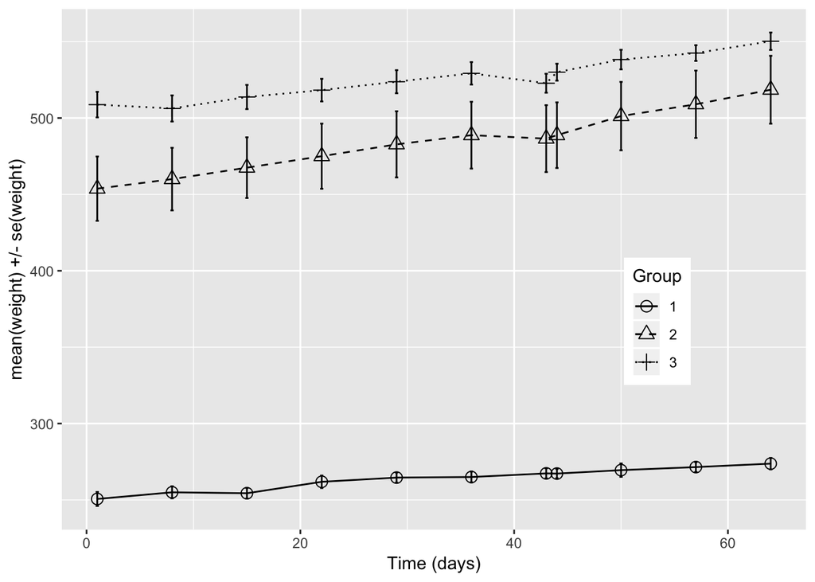

```r
# Mean response plot
n <- ratsl$Time %>%
  unique() %>%
  length()
ratsls <- ratsl %>%
  group_by(Group, Time) %>%
  summarise(mean = mean(Weight), se = sd(Weight)/sqrt(n)) %>%
  ungroup()
ggplot(ratsls, aes(x = Time, y = mean, linetype = Group, shape = Group)) +
  geom_line() +
  scale_linetype_manual(values = c(1,2,3)) +
  geom_point(size=3) +
  scale_shape_manual(values = c(1,2,3)) +
  geom_errorbar(aes(ymin=mean-se, ymax=mean+se, linetype="1"), width=0.3) +
  theme(legend.position = c(0.8,0.4)) +
  scale_y_continuous(name = "mean(weight) +/- se(weight)") +
  scale_x_continuous(name = "Time (days)")
```

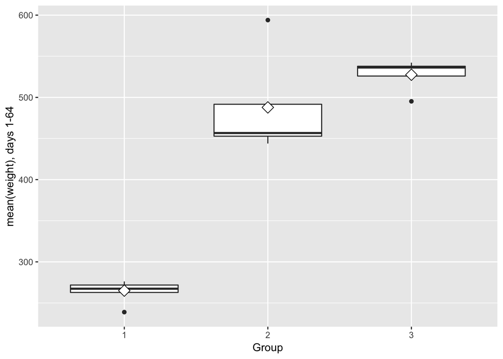

```r
# Boxplot
ratsl64 <- ratsl %>%
  filter(Time > 1) %>%
  group_by(Group, ID) %>%
  summarise(mean = mean(Weight)) %>%
  ungroup()
ggplot(ratsl64, aes(x = Group, y = mean)) +
  geom_boxplot() +
  stat_summary(fun.y = "mean", geom = "point", shape=23, size=4, fill = "white") +
  scale_y_continuous(name = "mean(weight), days 1-64")
```

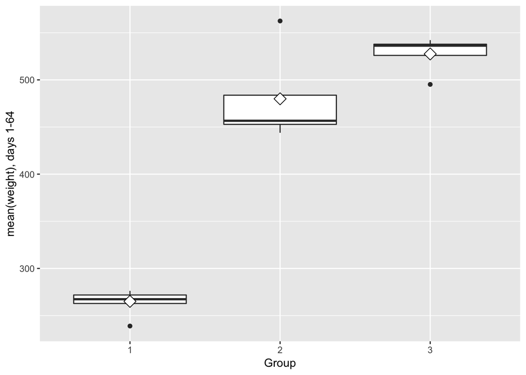

```r
# Boxplot without the outlier
ratsl641 <- ratsl %>%
  filter(Time > 1, Weight < 580) %>%
  group_by(Group, ID) %>%
  summarise(mean = mean(Weight)) %>%
  ungroup()
ggplot(ratsl641, aes(x = Group, y = mean)) +
  geom_boxplot() +
  stat_summary(fun.y = "mean", geom = "point", shape=23, size=4, fill = "white") +
  scale_y_continuous(name = "mean(weight), days 1-64")
```

```r
rats <- fread("https://raw.githubusercontent.com/KimmoVehkalahti/MABS/master/Examples/data/rats.txt", drop = 1)
str(rats)
```

```
## Classes 'data.table' and 'data.frame':   16 obs. of  13 variables:
##  $ ID   : int  1 2 3 4 5 6 7 8 9 10 ...
##  $ Group: int  1 1 1 1 1 1 1 1 2 2 ...
##  $ WD1  : int  240 225 245 260 255 260 275 245 410 405 ...
##  $ WD8  : int  250 230 250 255 260 265 275 255 415 420 ...
##  $ WD15 : int  255 230 250 255 255 270 260 260 425 430 ...
##  $ WD22 : int  260 232 255 265 270 275 270 268 428 440 ...
##  $ WD29 : int  262 240 262 265 270 275 273 270 438 448 ...
##  $ WD36 : int  258 240 265 268 273 277 274 265 443 460 ...
##  $ WD43 : int  266 243 267 270 274 278 276 265 442 458 ...
##  $ WD44 : int  266 244 267 272 273 278 271 267 446 464 ...
##  $ WD50 : int  265 238 264 274 276 284 282 273 456 475 ...
##  $ WD57 : int  272 247 268 273 278 279 281 274 468 484 ...
##  $ WD64 : int  278 245 269 275 280 281 284 278 478 496 ...
##  - attr(*, ".internal.selfref")=<externalptr>
```

```r
ratsl642 <- ratsl64 %>%
  mutate(baseline = rats$WD1)
fit <- lm(mean ~ baseline + Group, data = ratsl642)
anova(fit)
```

```
## Analysis of Variance Table
##
## Response: mean
##           Df Sum Sq Mean Sq   F value   Pr(>F)
## baseline   1 253625  253625 1859.8201 1.57e-14 ***
## Group      2    879     439    3.2219  0.07586 .
## Residuals 12   1636     136
## ---
## Signif. codes:  0 '***' 0.001 '**' 0.01 '*' 0.05 '.' 0.1 ' ' 1
```

2 -Analyses from ch.9

BPRSL data

```r
bprsl <- fread("~/Documents/IODS-project/data/bprsl.csv", drop = 1)
bprsl$week <- as.integer(substr(bprsl$week, 5, 5))
bprsl$treatment <- as.factor(bprsl$treatment)
bprsl$subject <- as.factor(bprsl$subject)
str(bprsl)
```

```
## Classes 'data.table' and 'data.frame':   360 obs. of  4 variables:
##  $ treatment: Factor w/ 2 levels "1","2": 1 1 1 1 1 1 1 1 1 1 ...
##  $ subject  : Factor w/ 20 levels "1","2","3","4",..: 1 2 3 4 5 6 7 8 9 10 ...
##  $ week     : int  0 0 0 0 0 0 0 0 0 0 ...
##  $ bprs     : int  42 58 54 55 72 48 71 30 41 57 ...
##  - attr(*, ".internal.selfref")=<externalptr>
```

```r
head(bprsl)
```

```
##    treatment subject week bprs
## 1:         1       1    0   42
## 2:         1       2    0   58
## 3:         1       3    0   54
## 4:         1       4    0   55
## 5:         1       5    0   72
## 6:         1       6    0   48
```

```r
summary(bprsl)
```

```
##  treatment    subject         week        bprs
##  1:180     1      : 18   Min.   :0   Min.   :18.00
##  2:180     2      : 18   1st Qu.:2   1st Qu.:27.00
##            3      : 18   Median :4   Median :35.00
##            4      : 18   Mean   :4   Mean   :37.66
##            5      : 18   3rd Qu.:6   3rd Qu.:43.00
##            6      : 18   Max.   :8   Max.   :95.00
##            (Other):252
```

```r
glimpse(bprsl)
```

```
## Observations: 360
## Variables: 4
## $ treatment <fct> 1, 1, 1, 1, 1, 1, 1, 1, 1, 1, 1, 1, 1, 1, 1, 1, 1, 1...
## $ subject   <fct> 1, 2, 3, 4, 5, 6, 7, 8, 9, 10, 11, 12, 13, 14, 15, 1...
## $ week      <int> 0, 0, 0, 0, 0, 0, 0, 0, 0, 0, 0, 0, 0, 0, 0, 0, 0, 0...
## $ bprs      <int> 42, 58, 54, 55, 72, 48, 71, 30, 41, 57, 30, 55, 36, ...
```

Now let’s move to the BPRSL data. Our dataset includes four variables: the id-variable “subject”, the time variable “week”, the variable for the treatment status “treatment” and the response variable “bprs”.

Graphical display of the data

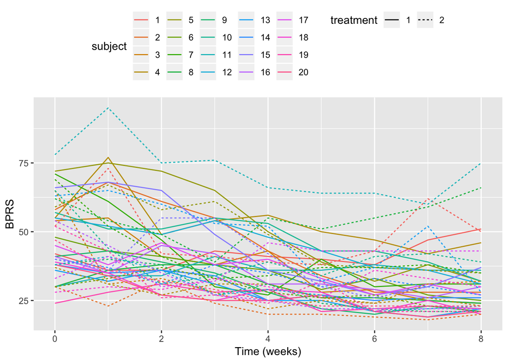

```r
ggplot(bprsl, aes(x = week, y = bprs, col = subject)) +
  geom_line(aes(linetype = treatment)) +
  scale_x_continuous(name = "Time (weeks)") +
  scale_y_continuous(name = "BPRS") +
  theme(legend.position = "top")
```

First let us experiment with some plots. At this point the BPRS-measure appears to have gradually decreased in the 8 week prediod of the data sample, undependant of the treatment status. Before further analysis, I doubt we can come into any significant conclusions.

```r
m <- lm(bprs ~ week + treatment, data = bprsl)
summary(m)
```

```
##
## Call:
## lm(formula = bprs ~ week + treatment, data = bprsl)
##
## Residuals:
##     Min      1Q  Median      3Q     Max
## -22.454  -8.965  -3.196   7.002  50.244
##
## Coefficients:
##             Estimate Std. Error t value Pr(>|t|)
## (Intercept)  46.4539     1.3670  33.982   <2e-16 ***
## week         -2.2704     0.2524  -8.995   <2e-16 ***
## treatment2    0.5722     1.3034   0.439    0.661
## ---
## Signif. codes:  0 '***' 0.001 '**' 0.01 '*' 0.05 '.' 0.1 ' ' 1
##
## Residual standard error: 12.37 on 357 degrees of freedom
## Multiple R-squared:  0.1851, Adjusted R-squared:  0.1806
## F-statistic: 40.55 on 2 and 357 DF,  p-value: < 2.2e-16
```

Now I’m attempting analysis with “linear mixed models”. These include “the random intercept model”, “the random intercept and slope model” and “the interaction model”, All of the models are similar, the 2nd and 3rd ones are simply expanded versions of “the random intercept model”. First I will use the naive linear model. This does not include the repeated measures structure of the data. The model indicates that the BPRS-measure decreases over time, and that this change is statistically significant. The average for the baseline BPRS-value of the subjects of treatment group two is slightly higher (Not significantly).

Random intercept model

```r
bprsl_m1 <- lmer(bprs ~ week + treatment + (1 | subject), data = bprsl, REML = FALSE)
summary(bprsl_m1)
```

```
## Linear mixed model fit by maximum likelihood  ['lmerMod']
## Formula: bprs ~ week + treatment + (1 | subject)
##    Data: bprsl
##
##      AIC      BIC   logLik deviance df.resid
##   2748.7   2768.1  -1369.4   2738.7      355
##
## Scaled residuals:
##     Min      1Q  Median      3Q     Max
## -3.0481 -0.6749 -0.1361  0.4813  3.4855
##
## Random effects:
##  Groups   Name        Variance Std.Dev.
##  subject  (Intercept)  47.41    6.885
##  Residual             104.21   10.208
## Number of obs: 360, groups:  subject, 20
##
## Fixed effects:
##             Estimate Std. Error t value
## (Intercept)  46.4539     1.9090  24.334
## week         -2.2704     0.2084 -10.896
## treatment2    0.5722     1.0761   0.532
##
## Correlation of Fixed Effects:
##            (Intr) week
## week       -0.437
## treatment2 -0.282  0.000
```

Random intercept and slope model

```r
bprsl_m2 <- lmer(bprs ~ week + treatment + (week | subject), data = bprsl, REML = FALSE)
summary(bprsl_m2)
```

```
## Linear mixed model fit by maximum likelihood  ['lmerMod']
## Formula: bprs ~ week + treatment + (week | subject)
##    Data: bprsl
##
##      AIC      BIC   logLik deviance df.resid
##   2745.4   2772.6  -1365.7   2731.4      353
##
## Scaled residuals:
##     Min      1Q  Median      3Q     Max
## -2.8919 -0.6194 -0.0691  0.5531  3.7976
##
## Random effects:
##  Groups   Name        Variance Std.Dev. Corr
##  subject  (Intercept) 64.8202  8.0511
##           week         0.9608  0.9802   -0.51
##  Residual             97.4307  9.8707
## Number of obs: 360, groups:  subject, 20
##
## Fixed effects:
##             Estimate Std. Error t value
## (Intercept)  46.4539     2.1052  22.066
## week         -2.2704     0.2977  -7.626
## treatment2    0.5722     1.0405   0.550
##
## Correlation of Fixed Effects:
##            (Intr) week
## week       -0.582
## treatment2 -0.247  0.000
```

Now we are enabling a different slopes for observations, changing the standard errors. The standard error on “treatment” becomes smaller, while the errors for the intercept and for “week” grow.

Next we modify the model to allow our variables to interact:

```r
bprsl_m3 <- lmer(bprs ~ week + treatment + (week | subject) + week*treatment, data = bprsl, REML = FALSE)
summary(bprsl_m3)
```

```
## Linear mixed model fit by maximum likelihood  ['lmerMod']
## Formula: bprs ~ week + treatment + (week | subject) + week * treatment
##    Data: bprsl
##
##      AIC      BIC   logLik deviance df.resid
##   2744.3   2775.4  -1364.1   2728.3      352
##
## Scaled residuals:
##     Min      1Q  Median      3Q     Max
## -3.0512 -0.6271 -0.0767  0.5288  3.9260
##
## Random effects:
##  Groups   Name        Variance Std.Dev. Corr
##  subject  (Intercept) 65.0016  8.0624
##           week         0.9688  0.9843   -0.51
##  Residual             96.4699  9.8219
## Number of obs: 360, groups:  subject, 20
##
## Fixed effects:
##                 Estimate Std. Error t value
## (Intercept)      47.8856     2.2522  21.262
## week             -2.6283     0.3589  -7.323
## treatment2       -2.2911     1.9090  -1.200
## week:treatment2   0.7158     0.4010   1.785
##
## Correlation of Fixed Effects:
##             (Intr) week   trtmn2
## week        -0.650
## treatment2  -0.424  0.469
## wek:trtmnt2  0.356 -0.559 -0.840
```

For “week”, the BPRS value decreased within the 8 week period in the treatment group one by approximately -2.6 points in a week (on average). That is statistically significant (t-value: >7). The coefficient on treatment variable indicates that the subjects in treatment group two had a slightly lower average baseline BPRS value. The interaction term shows that the decrease of the BPRS value was slower in treatment group two. These additional estimates are unfortunately not statistically significant. Now I can conclude that treatment in group one seems more efficient, even if this difference isn’t significant statistically.

Likelihood ratio test

```r
anova(bprsl_m2, bprsl_m1)
```

```
## Data: bprsl
## Models:
## bprsl_m1: bprs ~ week + treatment + (1 | subject)
## bprsl_m2: bprs ~ week + treatment + (week | subject)
##          Df    AIC    BIC  logLik deviance  Chisq Chi Df Pr(>Chisq)
## bprsl_m1  5 2748.7 2768.1 -1369.4   2738.7
## bprsl_m2  7 2745.4 2772.6 -1365.7   2731.4 7.2721      2    0.02636 *
## ---
## Signif. codes:  0 '***' 0.001 '**' 0.01 '*' 0.05 '.' 0.1 ' ' 1
```

```r
anova(bprsl_m3, bprsl_m2)
```

```
## Data: bprsl
## Models:
## bprsl_m2: bprs ~ week + treatment + (week | subject)
## bprsl_m3: bprs ~ week + treatment + (week | subject) + week * treatment
##          Df    AIC    BIC  logLik deviance  Chisq Chi Df Pr(>Chisq)
## bprsl_m2  7 2745.4 2772.6 -1365.7   2731.4
## bprsl_m3  8 2744.3 2775.4 -1364.1   2728.3 3.1712      1    0.07495 .
## ---
## Signif. codes:  0 '***' 0.001 '**' 0.01 '*' 0.05 '.' 0.1 ' ' 1
```

OBS VS. Fitted values

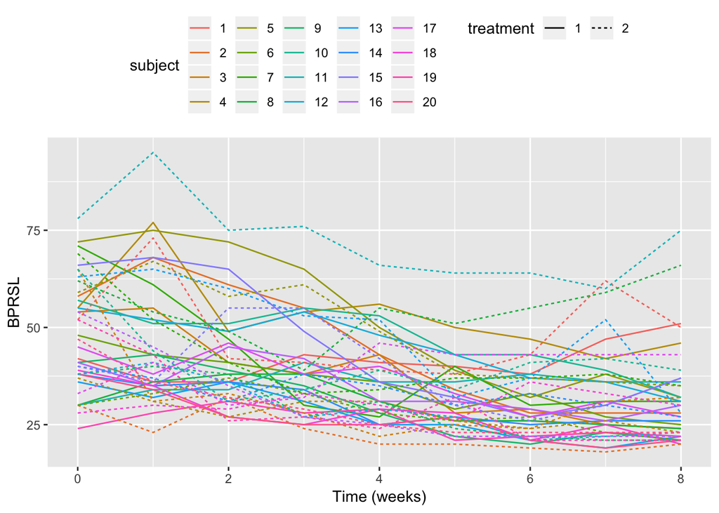

```r
ggplot(bprsl, aes(x = week, y = bprs, col = subject)) +
  geom_line(aes(linetype = treatment)) +
  scale_x_continuous(name = "Time (weeks)") +
  scale_y_continuous(name = "BPRSL") +
  theme(legend.position = "top")
```

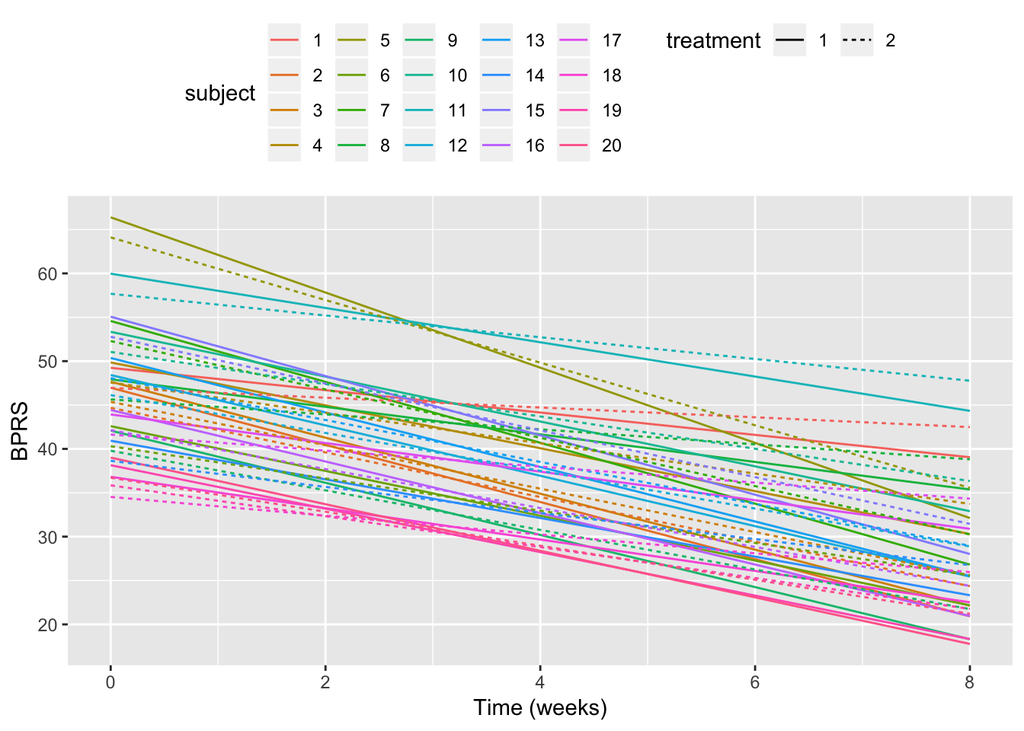

```r
fitted <- fitted(bprsl_m3)
bprsl$fitted <- fitted
ggplot(bprsl, aes(x = week, y = fitted, col = subject)) +
  geom_line(aes(linetype = treatment)) +
  scale_x_continuous(name = "Time (weeks)") +
  scale_y_continuous(name = "BPRS") +
  theme(legend.position = "top")
```

There are mainly two clear observations that I’m able to make regarding this model. 1. The average intercept in treatment group two appears to be smaller than in treatment group one. 2. Slopes for the data of the 1st treatment group seem a bit steeper than those of the 2nd group.